# Nest count estimation Wermon

# Wermon

Moving on to the Wermon dataset.

```r
data.0.W <- read.csv('data/W_nests.csv')
# create regularly spaced time series:
data.2.W <- data.frame(Year = rep(min(data.0.W$Year_begin,
                                       na.rm = T):max(data.0.W$Year_begin,
                                                      na.rm = T),
                                   each = 12),
                        Month_begin = rep(1:12,
                                          max(data.0.W$Year_begin,
                                              na.rm = T) -
                                            min(data.0.W$Year_begin,
                                                na.rm = T) + 1)) %>%
  mutate(begin_date = as.Date(paste(Year,
                                    Month_begin,
                                    '01', sep = "-"),
                              format = "%Y-%m-%d"),
         Frac.Year = Year + (Month_begin-0.5)/12) %>%
  select(Year, begin_date, Frac.Year)
# create time-duration filed (in yrs)
# define dates with begin and end dates:
data.0.W %>% mutate(begin_date = as.Date(paste(Year_begin,
                                                Month_begin,
                                                '01', sep = "-"),
                                          format = "%Y-%m-%d")) %>%
  mutate(end_day = if_else(Month_end == 1 | Month_end == 3 | Month_end == 5 |
                             Month_end == 7 | Month_end == 8 | Month_end == 10 |
                             Month_end == 12, 31,
                           if_else(Month_end == 2,
                                   if_else(leap_year(Year_end) == TRUE,
                                           29, 28), 30))) %>%
  mutate(end_date = as.Date(paste(Year_end, Month_end, end_day,
                                  sep = "-"),
                            format = "%Y-%m-%d")) %>%
  mutate(cumu_days = as.numeric(end_date - begin_date[1] + 1),
         num_days = as.numeric(end_date - begin_date) + 1,
         Year = Year_begin,
         Month = Month_begin,
         f_month = as.factor(Month),
         f_year = as.factor(Year),
         Nests = W.1)   %>%
  select(Year, Month, begin_date,
         end_date, num_days, cumu_days,
         f_month, f_year,
         Nests)  %>%
  na.omit() %>%
  right_join(.,data.2.W, by = "begin_date") %>%
  reshape::sort_df(.,vars = "Frac.Year") -> data.1.W
```

Raw data look like this.

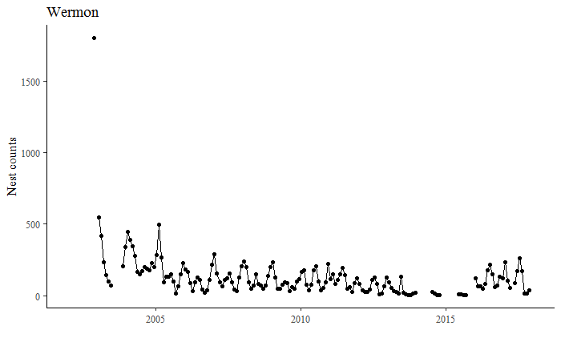

```r
p.W.all <- ggplot(data.1.W) +
  geom_point(aes(x = Frac.Year, y = Nests)) +
  geom_line(aes(x = Frac.Year, y = Nests)) +
  labs(title = 'Wermon', x = '',
       y = "Nest counts")
if (save.fig) ggsave(filename = 'figures/W_all.png',
                     plot = p.W.all,
                     dpi = 600, height = 6,
                     width = 8, units = "in")
p.W.all
```

The first data point seems very large… Also, we see a lot of missing values between the mid 2013 and 2016. Data for 2013 seem not so reliable. That’s a tough one to fill because no data are available at all… Take a look at annual fluctuations:

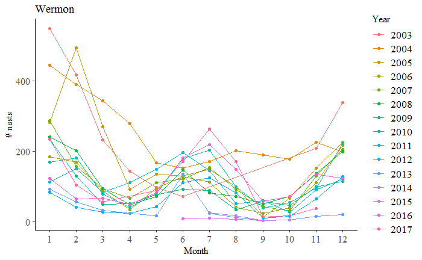

```r
data.1.W %>% filter(Nests < 1000) -> data.1.W.2003
p.W.monthly <- ggplot(data.1.W.2003) +
  geom_point(aes(x = Month, y = Nests, color = f_year)) +
  geom_line(aes(x = Month, y = Nests, color = f_year)) +
  scale_x_continuous(breaks = seq(1, 12, 1)) +
  labs(x = 'Month', y = '# nests', title = "Wermon",
       color = "Year")  +
  theme(axis.text = element_text(size = 12),
        text = element_text(size = 12))
if (save.fig) ggsave(filename = 'figures/W_monthly.png',
                     plot = p.W.monthly,
                     dpi = 600, height = 6,
                     width = 8, units = "in")
p.W.monthly
```

There are summer and winter peaks: higher values are found in June, July, August, November, December, January, and February. 2003, 2004 and 2005 seem to be outliers with respect to within-year trend, so as 2015. So, I remove them.

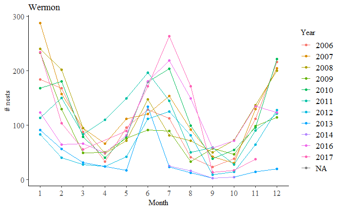

```r
data.1.W %>% filter(Year.y > 2005 & Year.y != 2015) -> data.1.W.2006
p.W.monthly.2006 <- ggplot(data.1.W.2006) +
  geom_point(aes(x = Month, y = Nests, color = f_year)) +
  geom_line(aes(x = Month, y = Nests, color = f_year)) +
  scale_x_continuous(breaks = seq(1, 12, 1)) +
  labs(x = 'Month', y = '# nests', title = "Wermon",
       color = "Year")  +
  theme(axis.text = element_text(size = 12),
        text = element_text(size = 12))
if (save.fig) ggsave(filename = 'figures/W_monthly_2006.png',
                     plot = p.W.monthly.2006,
                     dpi = 600, height = 6,
                     width = 8, units = "in")
p.W.monthly.2006
```

The pattern looks more prominent between 2006 and 2017 (2015 are missing). Low counts happen in March, April, September, and October.

When converting counts into log(counts);

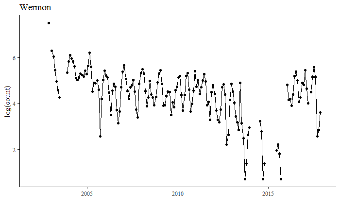

```r
p.W.log.count <- ggplot(data.1.W) +
  geom_point(aes(x = Frac.Year, y = log(Nests))) +
  geom_line(aes(x = Frac.Year, y = log(Nests))) +
  labs(x = "", y = "log(count)", title = "Wermon")
if (save.fig) ggsave(filename = 'figures/W_log_count.png',
                     plot = p.W.log.count,
                     dpi = 600, height = 6,
                     width = 8, units = "in")
p.W.log.count
```

First, the entire data are fit with the model with two variance terms; one for low count month, i.e., March, April, September and October, and another for the rest. Results are stored in a .RData file. zm is the posterior samples, Xs.stats.W is the estimated values of the process model, and ys.stats.W is the data.

```r
load("RData/SSAR1_month_W_all_2018-06-12.RData")
zm.W_all <- results.Warmon_SSAR1_month_all$zm
Xs.stats.W_all <- results.Warmon_SSAR1_month_all$Xs.stats
ys.stats.W_all <- results.Warmon_SSAR1_month_all$ys.stats
# Gelman-diagnostic seems okay.
#results.Warmon_SSAR1_month_To2013$g.diag
```

The JAGS model for this analysis is in the following. jm is the JAGS model as it was compiled during the run.

```r
results.Warmon_SSAR1_month_all$jm
```

```
JAGS model:

# simple state space AR1 model for turtle nesting
# original code from Lab 7, Introduction to Bayesian Time-Series
# analysis using Jags. Univ Washington:
# https://www.scribd.com/document/373707632/Lab-7-Fitting-models-with-JAGS-pdf

# Also can be found here:
# https://nwfsc-timeseries.github.io/atsa-labs/sec-jags-uss.html

model{
    for (t in 2:T){
        # process
        predX[t] <- theta * X[t-1]
        # one variance for Mar, Apr, Sep, and Oct and another for others
        tau.pro[t] <- ifelse(m[t] == 3 || m[t] == 4 || m[t] == 9 || m[t] == 10, tau.pro1, tau.pro2)
        X[t] ~ dnorm(predX[t], tau.pro[t])T(0,)

        # observation - not sure wht this predY does... shouldn't this be
        # the same as X[t]?
        predY[t] <- X[t]
        y[t] ~ dnorm(X[t], tau.obs)
    }

    X[1] <- mu
    predY[1] <- X[1]
    y[1] ~ dnorm(X[1], tau.obs)T(0,)

    mu ~ dnorm(0, 0.01)
    sigma.pro1 ~ dunif(0, 200)
    tau.pro1 <- 1/(sigma.pro1 * sigma.pro1)

    sigma.pro2 ~ dunif(0, 500)
    tau.pro2 <- 1/(sigma.pro2 * sigma.pro2)

    sigma.obs ~ dunif(0, 200)
    tau.obs <- 1/(sigma.obs * sigma.obs)

    theta ~  dnorm(0, 10)
}
Fully observed variables:
 T m
Partially observed variables:
 y
```

And the data are here. y is the observed nests, m is months, and T is the length of the time series. Note that the initial large count (1797) is included in this analysis.

```r
results.Warmon_SSAR1_month_all$bugs.data
```

```
$y
  [1]   NA   NA   NA   NA   NA   NA   NA   NA   NA   NA 1797   NA  548  417  232
 [16]  143   97   71   NA   NA   NA   NA  208  338  445  389  343  278  167  152
 [31]  170  202  189  178  226  198  282  494  269   91  134  130  148   99   13
 [46]   66  151  226  184  168   87   33   95  128  112   41   23   38  111  216
 [61]  287  157   94   66  111  120  153   92   42   30  129  204  240  202   94
 [76]   48   71  147   81   71   50   72  136  200  233  129   49   50   76   91
 [91]   89   33   57   46   98  114  168  180   78   40   79  179  203   99   38
[106]   54   95  221  113  150   83  110  149  196  144   50   59   27   90  121
[121]   83   40   27   24   42  111  125   81    9   14   64  127   91   56   31
[136]   24   17  134   23   12    2    4   14   19   NA   NA   NA   NA   NA   NA
[151]   25   16    2    4   NA   NA   NA   NA   NA   NA   NA    7    9    6    2
[166]   NA   NA   NA  123   64   66   49   81  180  219  149   58   71  135  123
[181]  234  103   55   NA   89  171  263  171   13   17   37   NA

$m
  [1]  1  2  3  4  5  6  7  8  9 10 11 12  1  2  3  4  5  6  7  8  9 10 11 12  1  2
 [27]  3  4  5  6  7  8  9 10 11 12  1  2  3  4  5  6  7  8  9 10 11 12  1  2  3  4
 [53]  5  6  7  8  9 10 11 12  1  2  3  4  5  6  7  8  9 10 11 12  1  2  3  4  5  6
 [79]  7  8  9 10 11 12  1  2  3  4  5  6  7  8  9 10 11 12  1  2  3  4  5  6  7  8
[105]  9 10 11 12  1  2  3  4  5  6  7  8  9 10 11 12  1  2  3  4  5  6  7  8  9 10
[131] 11 12  1  2  3  4  5  6  7  8  9 10 11 12  1  2  3  4  5  6  7  8  9 10 11 12
[157]  1  2  3  4  5  6  7  8  9 10 11 12  1  2  3  4  5  6  7  8  9 10 11 12  1  2
[183]  3  4  5  6  7  8  9 10 11 12

$T
[1] 192
```

Gelman diagnostic for convergence checking:

```r
results.Warmon_SSAR1_month_all$g.diag
```

```
Potential scale reduction factors:

           Point est. Upper C.I.
sigma.obs        1.03       1.05
sigma.pro1       1.00       1.00
sigma.pro2       1.00       1.00
theta            1.00       1.00

Multivariate psrf

1.01
```

It doesn’t look too bad.

The posterior of the process parameters look like these. First the densities.

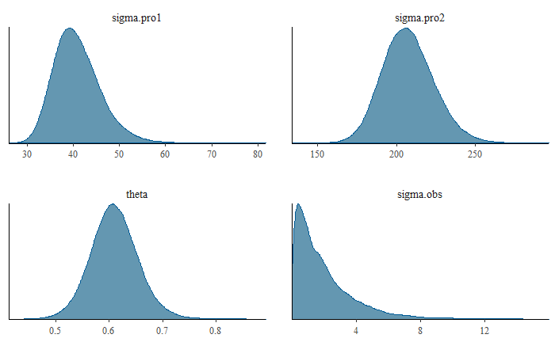

```r
mcmc_dens(zm.W_all, c("sigma.pro1", "sigma.pro2", "theta", "sigma.obs"))
```

Trace plots show how sigma.obs did not converge so well, compared with the other three parameters.

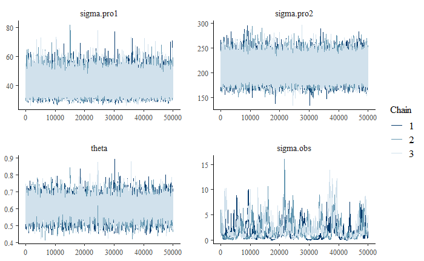

```r
mcmc_trace(zm.W_all, c("sigma.pro1", "sigma.pro2", "theta", "sigma.obs"))
```

Then look at the series including the predicted ones.

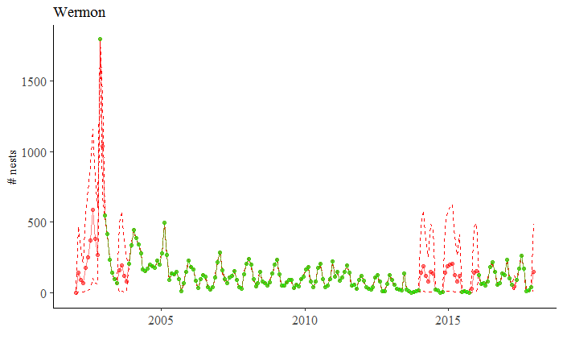

```r
p.W.predicted.var <- ggplot() +
  #geom_point(data = ys.stats,
  #           aes(x = time, y = mode_y), color = "blue") +
  #geom_line(data = Xs.stats,
  #          aes(x = time, y = mode_X), color = 'blue') +
  geom_line(data = Xs.stats.W_all,
            aes(x = time, y = high_X), color = "red",
            linetype = 2) +
  geom_line(data = Xs.stats.W_all,
            aes(x = time, y = low_X), color = "red",
            linetype = 2) +
  geom_point(data = Xs.stats.W_all,
             aes(x = time, y = median_X), color = "red",
             alpha = 0.5) +
  geom_line(data = Xs.stats.W_all,
            aes(x = time, y = median_X), color = "red",
            alpha = 0.5) +
  geom_point(data = ys.stats.W_all,
             aes(x = time, y = obsY), color = "green",
             alpha = 0.5)+
  geom_line(data = ys.stats.W_all,
             aes(x = time, y = obsY), color = "green",
             alpha = 0.5) +
  labs(x = '', y = '# nests', title = "Wermon")  +
  theme(axis.text = element_text(size = 12),
        text = element_text(size = 12))
if (save.fig) ggsave(filename = 'figures/W_predicted_var_theta.png',
                     plot = p.W.predicted.var,
                     dpi = 600, height = 6,
                     width = 8, units = "in")
p.W.predicted.var
```

Red dots are the estimated values, green dots are the observed values, dashed lines are the 95% credible intervals. Seemed to fit fairly well.

```r
dif.Xy_all <- sum((na.omit(Xs.stats.W_all$median_X - ys.stats.W_all$obsY))^2)
dif.Xy_all
```

```
[1] 0.09535969
```

The sum of squared differences between observed and predicted is `0.0954` where there were `159` data points.

I also tried the two-theta two-tau model as it was used for data from JM.

```r
#rm(list = c("results.Warmon_SSAR1_month_all"))
load("RData/SSAR1_month_W_var_theta_all_2018-06-12.RData")
zm.W_all2 <- results.W_SSAR1_month_var_theta$zm
Xs.stats.W_all2 <- results.W_SSAR1_month_var_theta$Xs.stats
ys.stats.W_all2 <- results.W_SSAR1_month_var_theta$ys.stats
# Gelman-diagnostic seems okay.
#results.Warmon_SSAR1_month_To2013$g.diag
```

In addition to the two taus as in the previous model, it has two “slope” parameters: one (theta.1) is for May, June, November, and December (increasing months) and the other (theta.2) is for the rest.

The JAGS model is the following:

```r
results.W_SSAR1_month_var_theta$jm
```

```
JAGS model:

# simple state space AR1 model for turtle nesting
# original code from Lab 7, Introduction to Bayesian Time-Series
# analysis using Jags. Univ Washington:
# https://www.scribd.com/document/373707632/Lab-7-Fitting-models-with-JAGS-pdf

# Also can be found here:
# https://nwfsc-timeseries.github.io/atsa-labs/sec-jags-uss.html
#
# For this model, I added another theta. Two thetas are used for increasing
# and decreasing months within each year.

model{
    for (t in 2:T){
        # process
        theta[t] <- ifelse(m[t] ==5 || m[t] == 6 || m[t] == 11 || m[t] == 12, theta.1, theta.2)
        predX[t] <- theta[t] * X[t-1]

        tau.pro[t] <- ifelse(m[t] == 3 || m[t] == 4 || m[t] == 9 || m[t] == 10, tau.pro1, tau.pro2)
        X[t] ~ dnorm(predX[t], tau.pro[t])T(0,)

        # observation
        predY[t] <- X[t]
        y[t] ~ dnorm(X[t], tau.obs)

    }

    X[1] <- mu
    predY[1] <- X[1]
    y[1] ~ dnorm(X[1], tau.obs)T(0,)

    mu ~ dnorm(0, 0.01)
    sigma.pro1 ~ dunif(0, 600)
    tau.pro1 <- 1/(sigma.pro1 * sigma.pro1)

    sigma.pro2 ~ dunif(0, 600)
    tau.pro2 <- 1/(sigma.pro2 * sigma.pro2)

    sigma.obs ~ dunif(0, 200)
    tau.obs <- 1/(sigma.obs * sigma.obs)

    theta.1 ~ dnorm(0, 10)
    theta.2 ~ dnorm(0, 10)
}
Fully observed variables:
 T m
Partially observed variables:
 y
```

And data are here:

```r
results.W_SSAR1_month_var_theta$bugs.data
```

```
$y
  [1]   NA   NA   NA   NA   NA   NA   NA   NA   NA   NA 1797   NA  548  417  232
 [16]  143   97   71   NA   NA   NA   NA  208  338  445  389  343  278  167  152
 [31]  170  202  189  178  226  198  282  494  269   91  134  130  148   99   13
 [46]   66  151  226  184  168   87   33   95  128  112   41   23   38  111  216
 [61]  287  157   94   66  111  120  153   92   42   30  129  204  240  202   94
 [76]   48   71  147   81   71   50   72  136  200  233  129   49   50   76   91
 [91]   89   33   57   46   98  114  168  180   78   40   79  179  203   99   38
[106]   54   95  221  113  150   83  110  149  196  144   50   59   27   90  121
[121]   83   40   27   24   42  111  125   81    9   14   64  127   91   56   31
[136]   24   17  134   23   12    2    4   14   19   NA   NA   NA   NA   NA   NA
[151]   25   16    2    4   NA   NA   NA   NA   NA   NA   NA    7    9    6    2
[166]   NA   NA   NA  123   64   66   49   81  180  219  149   58   71  135  123
[181]  234  103   55   NA   89  171  263  171   13   17   37   NA

$m
  [1]  1  2  3  4  5  6  7  8  9 10 11 12  1  2  3  4  5  6  7  8  9 10 11 12  1  2
 [27]  3  4  5  6  7  8  9 10 11 12  1  2  3  4  5  6  7  8  9 10 11 12  1  2  3  4
 [53]  5  6  7  8  9 10 11 12  1  2  3  4  5  6  7  8  9 10 11 12  1  2  3  4  5  6
 [79]  7  8  9 10 11 12  1  2  3  4  5  6  7  8  9 10 11 12  1  2  3  4  5  6  7  8
[105]  9 10 11 12  1  2  3  4  5  6  7  8  9 10 11 12  1  2  3  4  5  6  7  8  9 10
[131] 11 12  1  2  3  4  5  6  7  8  9 10 11 12  1  2  3  4  5  6  7  8  9 10 11 12
[157]  1  2  3  4  5  6  7  8  9 10 11 12  1  2  3  4  5  6  7  8  9 10 11 12  1  2
[183]  3  4  5  6  7  8  9 10 11 12

$T
[1] 192
```

Gelman diagnostic for convergence checking:

```r
results.W_SSAR1_month_var_theta$g.diag
```

```
Potential scale reduction factors:

           Point est. Upper C.I.
mu               1.00       1.00
sigma.obs        1.05       1.14
sigma.pro1       1.00       1.00
sigma.pro2       1.00       1.00
theta.1          1.00       1.01
theta.2          1.00       1.00

Multivariate psrf

1.03
```

The posterior densities look like the following:

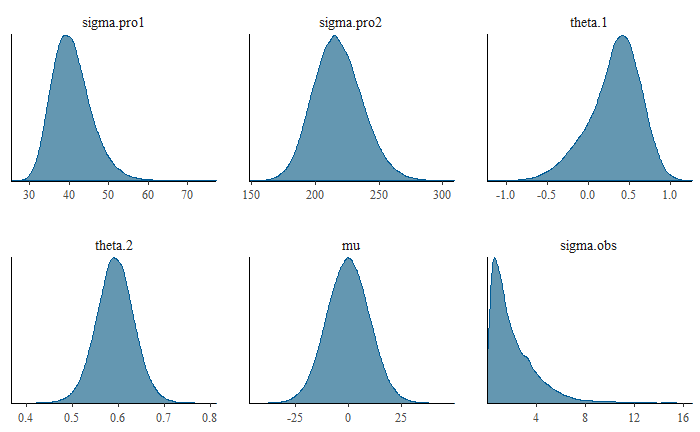

```r
mcmc_dens(zm.W_all2, c("sigma.pro1", "sigma.pro2",
                  "theta.1", "theta.2", "mu", "sigma.obs"))
```

Trace plots of these parameters look like the following.

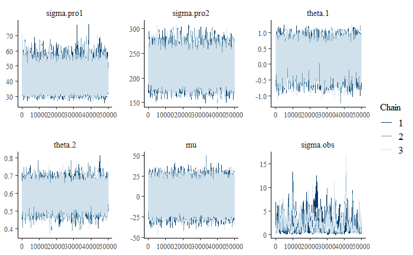

```r
mcmc_trace(zm.W_all2, c("sigma.pro1", "sigma.pro2",
                  "theta.1", "theta.2", "mu", "sigma.obs"))
```

Look at the series including the predicted ones.

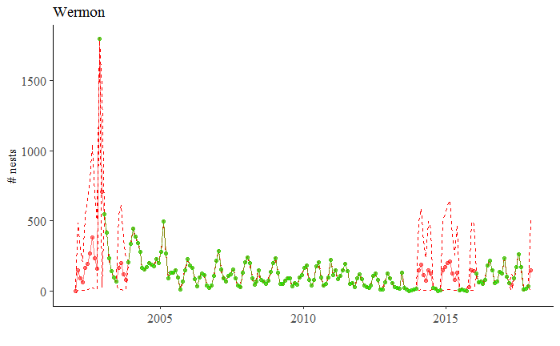

```r
p.W.predicted.var <- ggplot() +
  #geom_point(data = ys.stats,
  #           aes(x = time, y = mode_y), color = "blue") +
  #geom_line(data = Xs.stats,
  #          aes(x = time, y = mode_X), color = 'blue') +
  geom_line(data = Xs.stats.W_all2,
            aes(x = time, y = high_X), color = "red",
            linetype = 2) +
  geom_line(data = Xs.stats.W_all2,
            aes(x = time, y = low_X), color = "red",
            linetype = 2) +
  geom_point(data = Xs.stats.W_all2,
             aes(x = time, y = median_X), color = "red",
             alpha = 0.5) +
  geom_line(data = Xs.stats.W_all2,
            aes(x = time, y = median_X), color = "red",
            alpha = 0.5) +
  geom_point(data = ys.stats.W_all2,
             aes(x = time, y = obsY), color = "green",
             alpha = 0.5)+
  geom_line(data = ys.stats.W_all2,
             aes(x = time, y = obsY), color = "green",
             alpha = 0.5) +
  labs(x = '', y = '# nests', title = "Wermon")  +
  theme(axis.text = element_text(size = 12),
        text = element_text(size = 12))
if (save.fig) ggsave(filename = 'figures/W_predicted_var_theta.png',
                     plot = p.W.predicted.var,
                     dpi = 600, height = 6,
                     width = 8, units = "in")
p.W.predicted.var
```

Results don’t look any different from before… but the credible intervals seem to be wider for 2014 - 2016.

```r
dif.Xy_all2 <- sum((na.omit(Xs.stats.W_all2$median_X - ys.stats.W_all2$obsY))^2)
dif.Xy_all2
```

```
[1] 0.2740326
```

The sum of squared differences between observed and predicted is `0.274` where there were `159` data points. This was larger than from the previous model. So, the first model seemed to be better than this one using that metric.

Next, I looked at whether or not the first few large data points and many missing data points may be affecting the predictions at later years. So, I took out before 2004 and see how that fits. I used the one-theta model.

```r
#rm(list = c("results.W_SSAR1_month_var_theta"))
load("RData/SSAR1_month_W_2004_2018-06-12.RData")
zm.W_2004 <- results.Warmon_SSAR1_month_2004$zm
Xs.stats.2004 <- results.Warmon_SSAR1_month_2004$Xs.stats
ys.stats.2004 <- results.Warmon_SSAR1_month_2004$ys.stats
```

Confirm the model is still the same.

```r
results.Warmon_SSAR1_month_2004$jm
```

```
JAGS model:

# simple state space AR1 model for turtle nesting
# original code from Lab 7, Introduction to Bayesian Time-Series
# analysis using Jags. Univ Washington:
# https://www.scribd.com/document/373707632/Lab-7-Fitting-models-with-JAGS-pdf

# Also can be found here:
# https://nwfsc-timeseries.github.io/atsa-labs/sec-jags-uss.html

model{
    for (t in 2:T){
        # process
        predX[t] <- theta * X[t-1]
        # one variance for Mar, Apr, Sep, and Oct and another for others
        tau.pro[t] <- ifelse(m[t] == 3 || m[t] == 4 || m[t] == 9 || m[t] == 10, tau.pro1, tau.pro2)
        X[t] ~ dnorm(predX[t], tau.pro[t])T(0,)

        # observation - not sure wht this predY does... shouldn't this be
        # the same as X[t]?
        predY[t] <- X[t]
        y[t] ~ dnorm(X[t], tau.obs)
    }

    X[1] <- mu
    predY[1] <- X[1]
    y[1] ~ dnorm(X[1], tau.obs)T(0,)

    mu ~ dnorm(0, 0.01)
    sigma.pro1 ~ dunif(0, 200)
    tau.pro1 <- 1/(sigma.pro1 * sigma.pro1)

    sigma.pro2 ~ dunif(0, 500)
    tau.pro2 <- 1/(sigma.pro2 * sigma.pro2)

    sigma.obs ~ dunif(0, 200)
    tau.obs <- 1/(sigma.obs * sigma.obs)

    theta ~  dnorm(0, 10)
}
Fully observed variables:
 T m
Partially observed variables:
 y
```

And the data:

```r
results.Warmon_SSAR1_month_2004$bugs.data
```

```
$y
  [1] 445 389 343 278 167 152 170 202 189 178 226 198 282 494 269  91 134 130 148
 [20]  99  13  66 151 226 184 168  87  33  95 128 112  41  23  38 111 216 287 157
 [39]  94  66 111 120 153  92  42  30 129 204 240 202  94  48  71 147  81  71  50
 [58]  72 136 200 233 129  49  50  76  91  89  33  57  46  98 114 168 180  78  40
 [77]  79 179 203  99  38  54  95 221 113 150  83 110 149 196 144  50  59  27  90
 [96] 121  83  40  27  24  42 111 125  81   9  14  64 127  91  56  31  24  17 134
[115]  23  12   2   4  14  19  NA  NA  NA  NA  NA  NA  25  16   2   4  NA  NA  NA
[134]  NA  NA  NA  NA   7   9   6   2  NA  NA  NA 123  64  66  49  81 180 219 149
[153]  58  71 135 123 234 103  55  NA  89 171 263 171  13  17  37  NA

$m
  [1]  1  2  3  4  5  6  7  8  9 10 11 12  1  2  3  4  5  6  7  8  9 10 11 12  1  2
 [27]  3  4  5  6  7  8  9 10 11 12  1  2  3  4  5  6  7  8  9 10 11 12  1  2  3  4
 [53]  5  6  7  8  9 10 11 12  1  2  3  4  5  6  7  8  9 10 11 12  1  2  3  4  5  6
 [79]  7  8  9 10 11 12  1  2  3  4  5  6  7  8  9 10 11 12  1  2  3  4  5  6  7  8
[105]  9 10 11 12  1  2  3  4  5  6  7  8  9 10 11 12  1  2  3  4  5  6  7  8  9 10
[131] 11 12  1  2  3  4  5  6  7  8  9 10 11 12  1  2  3  4  5  6  7  8  9 10 11 12
[157]  1  2  3  4  5  6  7  8  9 10 11 12

$T
[1] 168
```

Gelman diagnostic:

```r
results.Warmon_SSAR1_month_2004$g.diag
```

```
Potential scale reduction factors:

           Point est. Upper C.I.
sigma.obs           1       1.00
sigma.pro1          1       1.01
sigma.pro2          1       1.00
theta               1       1.00

Multivariate psrf

1
```

According to the Gelman diagnostic, convergence was reached for these parameters.

Posterior densities of the model parameters:

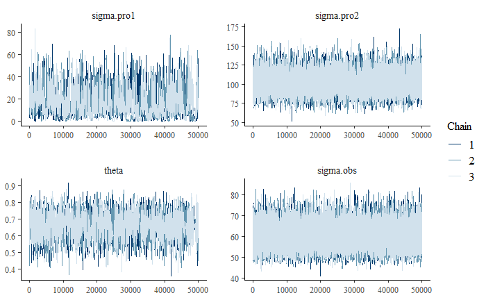

```r
mcmc_trace(zm.W_2004, c("sigma.pro1", "sigma.pro2",
                    "theta", "sigma.obs"))
```

And the density plots.

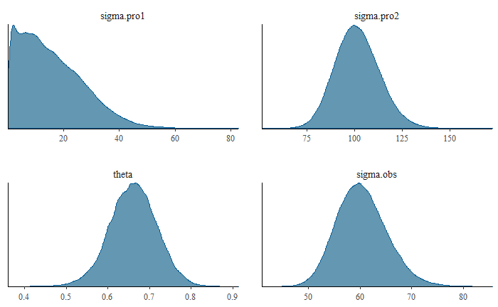

```r
mcmc_dens(zm.W_2004, c("sigma.pro1", "sigma.pro2",
                   "theta", "sigma.obs"))
```

sigma.pro1, SD for the low count months (March, April, September, and October), did not converge well and was smaller than when the entire data were used (mean = `15.8` and SD = `11.3`). The posterior for the SD of observation model (sigma.obs) looks a lot better than the previous models and the distribution is over larger values (mean = `60.1` and SD = `4.69`)

Predictions series look like this.

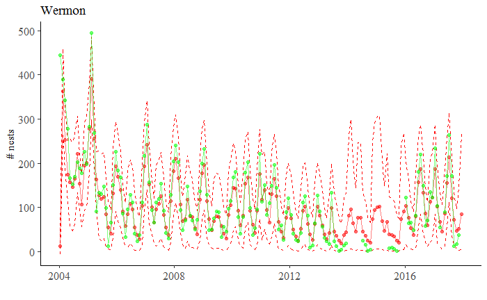

```r
p.W.predicted.var.2004 <- ggplot() +
  #geom_point(data = ys.stats,
  #           aes(x = time, y = mode_y), color = "blue") +
  #geom_line(data = Xs.stats,
  #          aes(x = time, y = mode_X), color = 'blue') +
  geom_line(data = Xs.stats.2004,
            aes(x = time, y = high_X), color = "red",
            linetype = 2) +
  geom_line(data = Xs.stats.2004,
            aes(x = time, y = low_X), color = "red",
            linetype = 2) +
  geom_point(data = Xs.stats.2004,
             aes(x = time, y = median_X), color = "red",
             alpha = 0.5) +
  geom_line(data = Xs.stats.2004,
            aes(x = time, y = median_X), color = "red",
            alpha = 0.5) +
  geom_point(data = ys.stats.2004,
             aes(x = time, y = obsY), color = "green",
             alpha = 0.5)+
  geom_line(data = ys.stats.2004,
             aes(x = time, y = obsY), color = "green",
             alpha = 0.5) +
  labs(x = '', y = '# nests', title = "Wermon")  +
  theme(axis.text = element_text(size = 12),
        text = element_text(size = 12))
if (save.fig) ggsave(filename = 'figures/W_predicted_var_2004.png',
                     plot = p.W.predicted.var.2004,
                     dpi = 600, height = 6,
                     width = 8, units = "in")
p.W.predicted.var.2004
```

The crediblel intervals for the missing data in 2014 and 2015 look better than the last run. But… I don’t understand why the median of predicted values don’t match the observed in this case… are they skewed distributions? So, the means may match with the observed? I think the reason is that the posterior on sigma.obs is a lot bigger than before.

```r
dif.Xy_2004 <- sum((na.omit(Xs.stats.2004$median_X - ys.stats.2004$obsY))^2)
dif.Xy_2004
```

```
[1] 293889.6
```

The squared sum of differences between observed and predicted is `2.94\times 10^{5}` where there were `150` data points. This was larger than from the previous models. So, the first model seemed to be better than this one using that metric.

Now, how about including starting from 2006?

```r
load("RData/SSAR1_month_W_2006_2018-06-12.RData")
zm.W_2006 <- results.Warmon_SSAR1_month_2006$zm
Xs.stats.2006 <- results.Warmon_SSAR1_month_2006$Xs.stats
ys.stats.2006 <- results.Warmon_SSAR1_month_2006$ys.stats
```

Confirm the model is still the same.

```r
results.Warmon_SSAR1_month_2006$jm
```

```
JAGS model:

# simple state space AR1 model for turtle nesting
# original code from Lab 7, Introduction to Bayesian Time-Series
# analysis using Jags. Univ Washington:
# https://www.scribd.com/document/373707632/Lab-7-Fitting-models-with-JAGS-pdf

# Also can be found here:
# https://nwfsc-timeseries.github.io/atsa-labs/sec-jags-uss.html

model{
    for (t in 2:T){
        # process
        predX[t] <- theta * X[t-1]
        # one variance for Mar, Apr, Sep, and Oct and another for others
        tau.pro[t] <- ifelse(m[t] == 3 || m[t] == 4 || m[t] == 9 || m[t] == 10, tau.pro1, tau.pro2)
        X[t] ~ dnorm(predX[t], tau.pro[t])T(0,)

        # observation - not sure wht this predY does... shouldn't this be
        # the same as X[t]?
        predY[t] <- X[t]
        y[t] ~ dnorm(X[t], tau.obs)
    }

    X[1] <- mu
    predY[1] <- X[1]
    y[1] ~ dnorm(X[1], tau.obs)T(0,)

    mu ~ dnorm(0, 0.01)
    sigma.pro1 ~ dunif(0, 200)
    tau.pro1 <- 1/(sigma.pro1 * sigma.pro1)

    sigma.pro2 ~ dunif(0, 500)
    tau.pro2 <- 1/(sigma.pro2 * sigma.pro2)

    sigma.obs ~ dunif(0, 200)
    tau.obs <- 1/(sigma.obs * sigma.obs)

    theta ~  dnorm(0, 10)
}
Fully observed variables:
 T m
Partially observed variables:
 y
```

And the data:

```r
results.Warmon_SSAR1_month_2006$bugs.data
```

```
$y
  [1] 184 168  87  33  95 128 112  41  23  38 111 216 287 157  94  66 111 120 153
 [20]  92  42  30 129 204 240 202  94  48  71 147  81  71  50  72 136 200 233 129
 [39]  49  50  76  91  89  33  57  46  98 114 168 180  78  40  79 179 203  99  38
 [58]  54  95 221 113 150  83 110 149 196 144  50  59  27  90 121  83  40  27  24
 [77]  42 111 125  81   9  14  64 127  91  56  31  24  17 134  23  12   2   4  14
 [96]  19  NA  NA  NA  NA  NA  NA  25  16   2   4  NA  NA  NA  NA  NA  NA  NA   7
[115]   9   6   2  NA  NA  NA 123  64  66  49  81 180 219 149  58  71 135 123 234
[134] 103  55  NA  89 171 263 171  13  17  37  NA

$m
  [1]  1  2  3  4  5  6  7  8  9 10 11 12  1  2  3  4  5  6  7  8  9 10 11 12  1  2
 [27]  3  4  5  6  7  8  9 10 11 12  1  2  3  4  5  6  7  8  9 10 11 12  1  2  3  4
 [53]  5  6  7  8  9 10 11 12  1  2  3  4  5  6  7  8  9 10 11 12  1  2  3  4  5  6
 [79]  7  8  9 10 11 12  1  2  3  4  5  6  7  8  9 10 11 12  1  2  3  4  5  6  7  8
[105]  9 10 11 12  1  2  3  4  5  6  7  8  9 10 11 12  1  2  3  4  5  6  7  8  9 10
[131] 11 12  1  2  3  4  5  6  7  8  9 10 11 12

$T
[1] 144
```

Gelman diagnostic:

```r
results.Warmon_SSAR1_month_2006$g.diag
```

```
Potential scale reduction factors:

           Point est. Upper C.I.
sigma.obs           1       1.00
sigma.pro1          1       1.01
sigma.pro2          1       1.00
theta               1       1.00

Multivariate psrf

1
```

Convergence seemed to reach fine. Posterior traces.

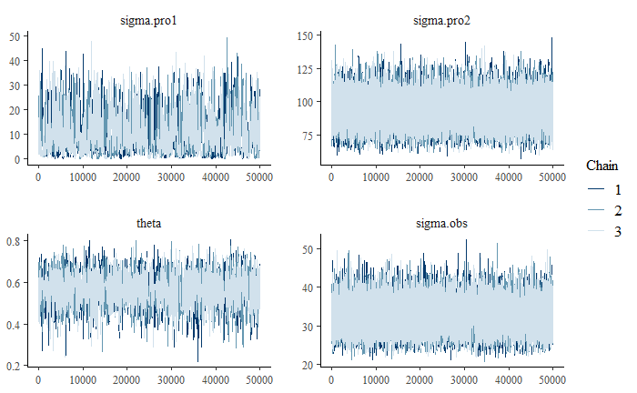

```r
mcmc_trace(zm.W_2006, c("sigma.pro1", "sigma.pro2",
                    "theta", "sigma.obs"))
```

And the density plots.

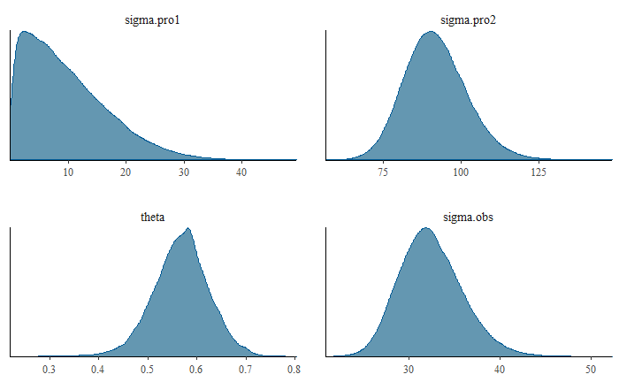

```r
mcmc_dens(zm.W_2006, c("sigma.pro1", "sigma.pro2",
                   "theta", "sigma.obs"))
```

Predictions series look like this.

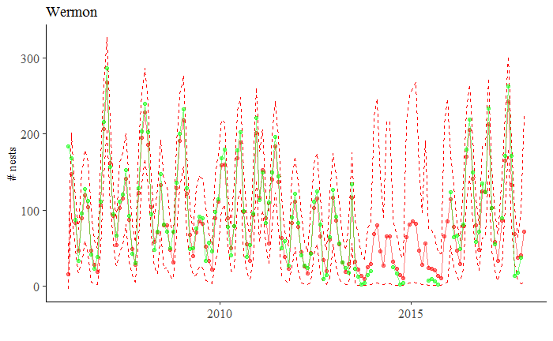

```r
p.W.predicted.var.2006 <- ggplot() +
  #geom_point(data = ys.stats,
  #           aes(x = time, y = mode_y), color = "blue") +
  #geom_line(data = Xs.stats,
  #          aes(x = time, y = mode_X), color = 'blue') +
  geom_line(data = Xs.stats.2006,
            aes(x = time, y = high_X), color = "red",
            linetype = 2) +
  geom_line(data = Xs.stats.2006,
            aes(x = time, y = low_X), color = "red",
            linetype = 2) +
  geom_point(data = Xs.stats.2006,
             aes(x = time, y = median_X), color = "red",
             alpha = 0.5) +
  geom_line(data = Xs.stats.2006,
            aes(x = time, y = median_X), color = "red",
            alpha = 0.5) +
  geom_point(data = ys.stats.2006,
             aes(x = time, y = obsY), color = "green",
             alpha = 0.5)+
  geom_line(data = ys.stats.2006,
             aes(x = time, y = obsY), color = "green",
             alpha = 0.5) +
  labs(x = '', y = '# nests', title = "Wermon")  +
  theme(axis.text = element_text(size = 12),
        text = element_text(size = 12))
if (save.fig) ggsave(filename = 'figures/W_predicted_var_2006.png',
                     plot = p.W.predicted.var.2006,
                     dpi = 600, height = 6,
                     width = 8, units = "in")
p.W.predicted.var.2006
```

```r
dif.Xy_2006 <- sum((na.omit(Xs.stats.2006$median_X - ys.stats.2006$obsY))^2)
dif.Xy_2006
```

```
[1] 53754.75
```

```r
summary.zm.W_2006 <- results.Warmon_SSAR1_month_2006$summary.zm
Xs.stats.2006$mean_X <- summary.zm.W_2006$statistics[grep(pattern = "X[/[]",
                                     row.names(summary.zm.W_2006$statistics)),
                                "Mean"]
```

I also looked at potential improvements in model fit if I included May as one of low number months. The following does the excatly the same series of analyses as before but adding one more month into the low-count months.

```r
load("RData/SSAR1_month_W_all_v2_2018-06-12.RData")
zm.W_all_v2 <- results.Warmon_SSAR1_month_all$zm
Xs.stats.v2 <- results.Warmon_SSAR1_month_all$Xs.stats
ys.stats.v2 <- results.Warmon_SSAR1_month_all$ys.stats
```

Confirm the model is still the same. Note that there is m[t] == 5 in the variance term. The comment was not updated…

```r
results.Warmon_SSAR1_month_all$jm
```

```
JAGS model:

# simple state space AR1 model for turtle nesting
# original code from Lab 7, Introduction to Bayesian Time-Series
# analysis using Jags. Univ Washington:
# https://www.scribd.com/document/373707632/Lab-7-Fitting-models-with-JAGS-pdf

# Also can be found here:
# https://nwfsc-timeseries.github.io/atsa-labs/sec-jags-uss.html

model{
    for (t in 2:T){
        # process
        predX[t] <- theta * X[t-1]
        # one variance for Mar, Apr, Sep, and Oct and another for others
        tau.pro[t] <- ifelse(m[t] == 3 || m[t] == 4 || m[t] == 5 || m[t] == 9 || m[t] == 10, tau.pro1, tau.pro2)
        X[t] ~ dnorm(predX[t], tau.pro[t])T(0,)

        # observation - not sure wht this predY does... shouldn't this be
        # the same as X[t]?
        predY[t] <- X[t]
        y[t] ~ dnorm(X[t], tau.obs)
    }

    X[1] <- mu
    predY[1] <- X[1]
    y[1] ~ dnorm(X[1], tau.obs)T(0,)

    mu ~ dnorm(0, 0.01)
    sigma.pro1 ~ dunif(0, 200)
    tau.pro1 <- 1/(sigma.pro1 * sigma.pro1)

    sigma.pro2 ~ dunif(0, 500)
    tau.pro2 <- 1/(sigma.pro2 * sigma.pro2)

    sigma.obs ~ dunif(0, 200)
    tau.obs <- 1/(sigma.obs * sigma.obs)

    theta ~  dnorm(0, 10)
}
Fully observed variables:
 T m
Partially observed variables:
 y
```

And the data:

```r
results.Warmon_SSAR1_month_all$bugs.data
```

```
$y
  [1]   NA   NA   NA   NA   NA   NA   NA   NA   NA   NA 1797   NA  548  417  232
 [16]  143   97   71   NA   NA   NA   NA  208  338  445  389  343  278  167  152
 [31]  170  202  189  178  226  198  282  494  269   91  134  130  148   99   13
 [46]   66  151  226  184  168   87   33   95  128  112   41   23   38  111  216
 [61]  287  157   94   66  111  120  153   92   42   30  129  204  240  202   94
 [76]   48   71  147   81   71   50   72  136  200  233  129   49   50   76   91
 [91]   89   33   57   46   98  114  168  180   78   40   79  179  203   99   38
[106]   54   95  221  113  150   83  110  149  196  144   50   59   27   90  121
[121]   83   40   27   24   42  111  125   81    9   14   64  127   91   56   31
[136]   24   17  134   23   12    2    4   14   19   NA   NA   NA   NA   NA   NA
[151]   25   16    2    4   NA   NA   NA   NA   NA   NA   NA    7    9    6    2
[166]   NA   NA   NA  123   64   66   49   81  180  219  149   58   71  135  123
[181]  234  103   55   NA   89  171  263  171   13   17   37   NA

$m
  [1]  1  2  3  4  5  6  7  8  9 10 11 12  1  2  3  4  5  6  7  8  9 10 11 12  1  2
 [27]  3  4  5  6  7  8  9 10 11 12  1  2  3  4  5  6  7  8  9 10 11 12  1  2  3  4
 [53]  5  6  7  8  9 10 11 12  1  2  3  4  5  6  7  8  9 10 11 12  1  2  3  4  5  6
 [79]  7  8  9 10 11 12  1  2  3  4  5  6  7  8  9 10 11 12  1  2  3  4  5  6  7  8
[105]  9 10 11 12  1  2  3  4  5  6  7  8  9 10 11 12  1  2  3  4  5  6  7  8  9 10
[131] 11 12  1  2  3  4  5  6  7  8  9 10 11 12  1  2  3  4  5  6  7  8  9 10 11 12
[157]  1  2  3  4  5  6  7  8  9 10 11 12  1  2  3  4  5  6  7  8  9 10 11 12  1  2
[183]  3  4  5  6  7  8  9 10 11 12

$T
[1] 192
```

Gelman diagnostic:

```r
results.Warmon_SSAR1_month_all$g.diag
```

```
Potential scale reduction factors:

           Point est. Upper C.I.
sigma.obs        1.04       1.11
sigma.pro1       1.00       1.00
sigma.pro2       1.00       1.00
theta            1.00       1.00

Multivariate psrf

1.02
```

Convergence seemed to reach fine. Posterior traces.

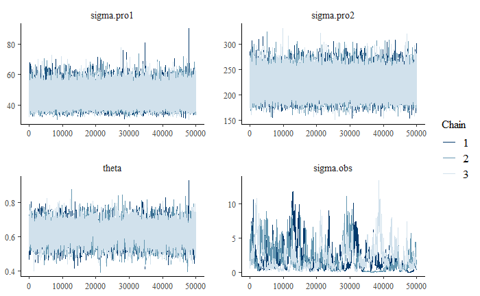

```r
mcmc_trace(zm.W_all_v2, c("sigma.pro1", "sigma.pro2",
                    "theta", "sigma.obs"))
```

Again, sigma.obs doesn’t look so good.

And the density plots.

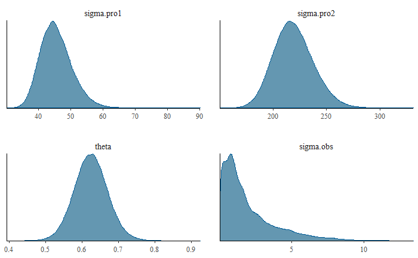

```r
mcmc_dens(zm.W_all_v2, c("sigma.pro1", "sigma.pro2",
                   "theta", "sigma.obs"))
```

Predictions series look like this.

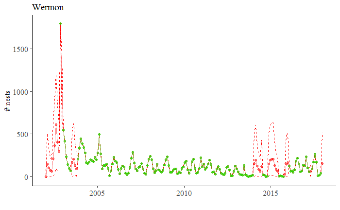

```r
p.W.predicted.var.v2 <- ggplot() +
  #geom_point(data = ys.stats,
  #           aes(x = time, y = mode_y), color = "blue") +
  #geom_line(data = Xs.stats,
  #          aes(x = time, y = mode_X), color = 'blue') +
  geom_line(data = Xs.stats.v2,
            aes(x = time, y = high_X), color = "red",
            linetype = 2) +
  geom_line(data = Xs.stats.v2,
            aes(x = time, y = low_X), color = "red",
            linetype = 2) +
  geom_point(data = Xs.stats.v2,
             aes(x = time, y = median_X), color = "red",
             alpha = 0.5) +
  geom_line(data = Xs.stats.v2,
            aes(x = time, y = median_X), color = "red",
            alpha = 0.5) +
  geom_point(data = ys.stats.v2,
             aes(x = time, y = obsY), color = "green",
             alpha = 0.5)+
  geom_line(data = ys.stats.v2,
             aes(x = time, y = obsY), color = "green",
             alpha = 0.5) +
  labs(x = '', y = '# nests', title = "Wermon")  +
  theme(axis.text = element_text(size = 12),
        text = element_text(size = 12))
if (save.fig) ggsave(filename = 'figures/W_predicted_var_all_v2.png',
                     plot = p.W.predicted.var.v2,
                     dpi = 600, height = 6,
                     width = 8, units = "in")
p.W.predicted.var.v2
```

```r
dif.Xy_v2 <- sum((na.omit(Xs.stats.v2$median_X - ys.stats.v2$obsY))^2)
dif.Xy_v2
```

```
[1] 0.07042073
```

This looks like what it was before - not much difference?

I also tried the two-theta two-tau model.

```r
#rm(list = c("results.Warmon_SSAR1_month_all"))
load("RData/SSAR1_month_W_var_theta_all_v2_2018-06-12.RData")
zm.W_all2_v2 <- results.W_SSAR1_month_var_theta$zm
Xs.stats.W_all2_v2 <- results.W_SSAR1_month_var_theta$Xs.stats
ys.stats.W_all2_v2 <- results.W_SSAR1_month_var_theta$ys.stats
# Gelman-diagnostic seems okay.
#results.Warmon_SSAR1_month_To2013$g.diag
```

The JAGS model is the following:

```r
results.W_SSAR1_month_var_theta$jm
```

```
JAGS model:

# simple state space AR1 model for turtle nesting
# original code from Lab 7, Introduction to Bayesian Time-Series
# analysis using Jags. Univ Washington:
# https://www.scribd.com/document/373707632/Lab-7-Fitting-models-with-JAGS-pdf

# Also can be found here:
# https://nwfsc-timeseries.github.io/atsa-labs/sec-jags-uss.html
#
# For this model, I added another theta. Two thetas are used for increasing
# and decreasing months within each year.

model{
    for (t in 2:T){
        # process
        theta[t] <- ifelse(m[t] == 6 || m[t] == 11 || m[t] == 12, theta.1, theta.2)
        predX[t] <- theta[t] * X[t-1]

        tau.pro[t] <- ifelse(m[t] == 3 || m[t] == 4 || m[t] == 5 || m[t] == 9 || m[t] == 10, tau.pro1, tau.pro2)
        X[t] ~ dnorm(predX[t], tau.pro[t])T(0,)

        # observation
        predY[t] <- X[t]
        y[t] ~ dnorm(X[t], tau.obs)

    }

    X[1] <- mu
    predY[1] <- X[1]
    y[1] ~ dnorm(X[1], tau.obs)T(0,)

    mu ~ dnorm(0, 0.01)
    sigma.pro1 ~ dunif(0, 600)
    tau.pro1 <- 1/(sigma.pro1 * sigma.pro1)

    sigma.pro2 ~ dunif(0, 600)
    tau.pro2 <- 1/(sigma.pro2 * sigma.pro2)

    sigma.obs ~ dunif(0, 200)
    tau.obs <- 1/(sigma.obs * sigma.obs)

    theta.1 ~ dnorm(0, 10)
    theta.2 ~ dnorm(0, 10)
}
Fully observed variables:
 T m
Partially observed variables:
 y
```

And data are here:

```r
results.W_SSAR1_month_var_theta$bugs.data
```

```
$y
  [1]   NA   NA   NA   NA   NA   NA   NA   NA   NA   NA 1797   NA  548  417  232
 [16]  143   97   71   NA   NA   NA   NA  208  338  445  389  343  278  167  152
 [31]  170  202  189  178  226  198  282  494  269   91  134  130  148   99   13
 [46]   66  151  226  184  168   87   33   95  128  112   41   23   38  111  216
 [61]  287  157   94   66  111  120  153   92   42   30  129  204  240  202   94
 [76]   48   71  147   81   71   50   72  136  200  233  129   49   50   76   91
 [91]   89   33   57   46   98  114  168  180   78   40   79  179  203   99   38
[106]   54   95  221  113  150   83  110  149  196  144   50   59   27   90  121
[121]   83   40   27   24   42  111  125   81    9   14   64  127   91   56   31
[136]   24   17  134   23   12    2    4   14   19   NA   NA   NA   NA   NA   NA
[151]   25   16    2    4   NA   NA   NA   NA   NA   NA   NA    7    9    6    2
[166]   NA   NA   NA  123   64   66   49   81  180  219  149   58   71  135  123
[181]  234  103   55   NA   89  171  263  171   13   17   37   NA

$m
  [1]  1  2  3  4  5  6  7  8  9 10 11 12  1  2  3  4  5  6  7  8  9 10 11 12  1  2
 [27]  3  4  5  6  7  8  9 10 11 12  1  2  3  4  5  6  7  8  9 10 11 12  1  2  3  4
 [53]  5  6  7  8  9 10 11 12  1  2  3  4  5  6  7  8  9 10 11 12  1  2  3  4  5  6
 [79]  7  8  9 10 11 12  1  2  3  4  5  6  7  8  9 10 11 12  1  2  3  4  5  6  7  8
[105]  9 10 11 12  1  2  3  4  5  6  7  8  9 10 11 12  1  2  3  4  5  6  7  8  9 10
[131] 11 12  1  2  3  4  5  6  7  8  9 10 11 12  1  2  3  4  5  6  7  8  9 10 11 12
[157]  1  2  3  4  5  6  7  8  9 10 11 12  1  2  3  4  5  6  7  8  9 10 11 12  1  2
[183]  3  4  5  6  7  8  9 10 11 12

$T
[1] 192
```

Gelman diagnostic for convergence checking:

```r
results.W_SSAR1_month_var_theta$g.diag
```

```
Potential scale reduction factors:

           Point est. Upper C.I.
mu                  1       1.00
sigma.obs           1       1.01
sigma.pro1          1       1.00
sigma.pro2          1       1.00
theta.1             1       1.00
theta.2             1       1.00

Multivariate psrf

1
```

The posterior densities look like the following:

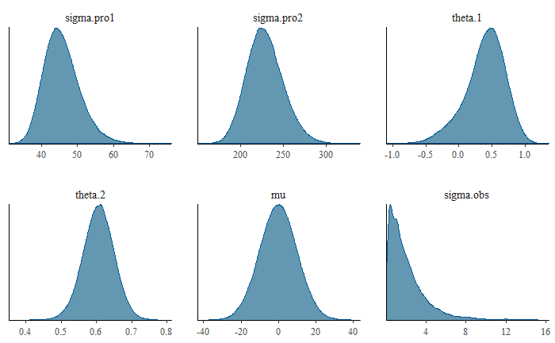

```r
mcmc_dens(zm.W_all2_v2, c("sigma.pro1", "sigma.pro2",
                  "theta.1", "theta.2", "mu", "sigma.obs"))
```

As they were in the previous model, the standard deviation of the lower count months is a lot smaller (mean = `45.7`, SD = `4.96`) than the other (mean = `228`, SD = `21.2`). The theta parameters, however, looked like they overlapped (theta.1: mean = `0.396`, SD = `0.304`, theta.2: mean = `0.606`, SD = `0.0443`). As it was in the previous model, sigma.obs did not look like it converged as well as for the other parameters (mean = `2.13`, SD = `2`), which had a long tail and not-so-smooth posterior.

Trace plots of these parameters look like the following.

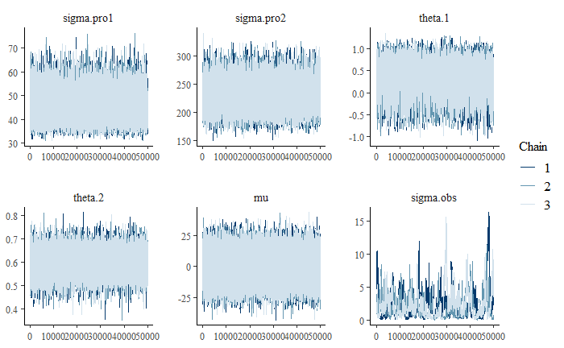

```r
mcmc_trace(zm.W_all2_v2, c("sigma.pro1", "sigma.pro2",
                  "theta.1", "theta.2", "mu", "sigma.obs"))
```

Look at the series including the predicted ones.

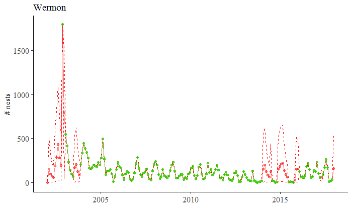

```r
p.W.predicted.var.theta_v2 <- ggplot() +
  #geom_point(data = ys.stats,
  #           aes(x = time, y = mode_y), color = "blue") +
  #geom_line(data = Xs.stats,
  #          aes(x = time, y = mode_X), color = 'blue') +
  geom_line(data = Xs.stats.W_all2_v2,
            aes(x = time, y = high_X), color = "red",
            linetype = 2) +
  geom_line(data = Xs.stats.W_all2_v2,
            aes(x = time, y = low_X), color = "red",
            linetype = 2) +
  geom_point(data = Xs.stats.W_all2_v2,
             aes(x = time, y = median_X), color = "red",
             alpha = 0.5) +
  geom_line(data = Xs.stats.W_all2_v2,
            aes(x = time, y = median_X), color = "red",
            alpha = 0.5) +
  geom_point(data = ys.stats.W_all2_v2,
             aes(x = time, y = obsY), color = "green",
             alpha = 0.5)+
  geom_line(data = ys.stats.W_all2_v2,
             aes(x = time, y = obsY), color = "green",
             alpha = 0.5) +
  labs(x = '', y = '# nests', title = "Wermon")  +
  theme(axis.text = element_text(size = 12),
        text = element_text(size = 12))
if (save.fig) ggsave(filename = 'figures/W_predicted_var_theta_v2.png',
                     plot = p.W.predicted.var.theta_v2,
                     dpi = 600, height = 6,
                     width = 8, units = "in")
p.W.predicted.var.theta_v2
```

Results don’t look any different from before… but the credible intervals seem to be wider for 2014 - 2016.

```r
dif.Xy_all2_v2 <- sum((na.omit(Xs.stats.W_all2_v2$median_X -
                                 ys.stats.W_all2_v2$obsY))^2)
dif.Xy_all2_v2
```

[output not shown]

The sum of squared differences between observed and predicted is `0.221` where there were `159` data points. This was larger than from the previous model. So, the first model seemed to be better than this one using that metric.

Next, I looked at whether or not the first few large data points and many missing data points may be affecting the predictions at later years. So, I took out before 2004 and see how that fits. I used the one-theta model.

```r
#rm(list = c("results.W_SSAR1_month_var_theta"))
load("RData/SSAR1_month_W_2004_v2_2018-06-12.RData")
zm.W_2004_v2 <- results.Warmon_SSAR1_month_2004$zm
Xs.stats.2004_v2 <- results.Warmon_SSAR1_month_2004$Xs.stats
ys.stats.2004_v2 <- results.Warmon_SSAR1_month_2004$ys.stats
```

Confirm the model is still the same.

```r
results.Warmon_SSAR1_month_2004$jm
```

```
JAGS model:

# simple state space AR1 model for turtle nesting
# original code from Lab 7, Introduction to Bayesian Time-Series
# analysis using Jags. Univ Washington:
# https://www.scribd.com/document/373707632/Lab-7-Fitting-models-with-JAGS-pdf

# Also can be found here:
# https://nwfsc-timeseries.github.io/atsa-labs/sec-jags-uss.html

model{
    for (t in 2:T){
        # process
        predX[t] <- theta * X[t-1]
        # one variance for Mar, Apr, Sep, and Oct and another for others
        tau.pro[t] <- ifelse(m[t] == 3 || m[t] == 4 || m[t] == 5 || m[t] == 9 || m[t] == 10, tau.pro1, tau.pro2)
        X[t] ~ dnorm(predX[t], tau.pro[t])T(0,)

        # observation - not sure wht this predY does... shouldn't this be
        # the same as X[t]?
        predY[t] <- X[t]
        y[t] ~ dnorm(X[t], tau.obs)
    }

    X[1] <- mu
    predY[1] <- X[1]
    y[1] ~ dnorm(X[1], tau.obs)T(0,)

    mu ~ dnorm(0, 0.01)
    sigma.pro1 ~ dunif(0, 200)
    tau.pro1 <- 1/(sigma.pro1 * sigma.pro1)

    sigma.pro2 ~ dunif(0, 500)
    tau.pro2 <- 1/(sigma.pro2 * sigma.pro2)

    sigma.obs ~ dunif(0, 200)
    tau.obs <- 1/(sigma.obs * sigma.obs)

    theta ~  dnorm(0, 10)
}
Fully observed variables:
 T m
Partially observed variables:
 y
```

And the data:

```r
results.Warmon_SSAR1_month_2004$bugs.data
```

```
$y
  [1] 445 389 343 278 167 152 170 202 189 178 226 198 282 494 269  91 134 130 148
 [20]  99  13  66 151 226 184 168  87  33  95 128 112  41  23  38 111 216 287 157
 [39]  94  66 111 120 153  92  42  30 129 204 240 202  94  48  71 147  81  71  50
 [58]  72 136 200 233 129  49  50  76  91  89  33  57  46  98 114 168 180  78  40
 [77]  79 179 203  99  38  54  95 221 113 150  83 110 149 196 144  50  59  27  90
 [96] 121  83  40  27  24  42 111 125  81   9  14  64 127  91  56  31  24  17 134
[115]  23  12   2   4  14  19  NA  NA  NA  NA  NA  NA  25  16   2   4  NA  NA  NA
[134]  NA  NA  NA  NA   7   9   6   2  NA  NA  NA 123  64  66  49  81 180 219 149
[153]  58  71 135 123 234 103  55  NA  89 171 263 171  13  17  37  NA

$m
  [1]  1  2  3  4  5  6  7  8  9 10 11 12  1  2  3  4  5  6  7  8  9 10 11 12  1  2
 [27]  3  4  5  6  7  8  9 10 11 12  1  2  3  4  5  6  7  8  9 10 11 12  1  2  3  4
 [53]  5  6  7  8  9 10 11 12  1  2  3  4  5  6  7  8  9 10 11 12  1  2  3  4  5  6
 [79]  7  8  9 10 11 12  1  2  3  4  5  6  7  8  9 10 11 12  1  2  3  4  5  6  7  8
[105]  9 10 11 12  1  2  3  4  5  6  7  8  9 10 11 12  1  2  3  4  5  6  7  8  9 10
[131] 11 12  1  2  3  4  5  6  7  8  9 10 11 12  1  2  3  4  5  6  7  8  9 10 11 12
[157]  1  2  3  4  5  6  7  8  9 10 11 12

$T
[1] 168
```

Gelman diagnostic:

```r
results.Warmon_SSAR1_month_2004$g.diag
```

```
Potential scale reduction factors:

           Point est. Upper C.I.
sigma.obs           1       1.01
sigma.pro1          1       1.01
sigma.pro2          1       1.00
theta               1       1.01

Multivariate psrf

1
```

According to the Gelman diagnostic, convergence was reached for these parameters.